# Udacity Data Analyst Nanodegree Project #2 - Investigate a Dataset (TMDB Movies)

### Dataset Observations:

**NOTE**: Analysis of the dataset shows there is opportunity to slim unnecessary columns. On the next section of the data cleaning process, we will also identify duplicate records and remove accordingly. As shown in the info() section above, there are attributes with missing records. We will use mean() to fill in missing values.

### Data Cleaning (Removing unnecessary data from the Dataset)

The following are the steps we will follow for the data cleaning process:

#### Step 1. Remove Unnecessary Columns

```python
# declare a new array of columns for removal
rm_cols=[ 'imdb_id', 'homepage', 'tagline', 'keywords', 'overview', 'release_date', 'budget_adj', 'revenue_adj']

#Removing the unwanted columns in the rm_cols array
movies_df= movies_df.drop(rm_cols,1)

#Confirm columns have been removed
movies_df.head(2)
```

|  | id | popularity | budget | revenue | original_title | cast | director | runtime | genres | production_companies | vote_count | vote_average | release_year |
| --- | --- | --- | --- | --- | --- | --- | --- | --- | --- | --- | --- | --- | --- |
| 0 | 135397 | 32.985763 | 150000000 | 1513528810 | Jurassic World | Chris Pratt\|Bryce Dallas Howard\|Irrfan Khan\|Vi... | Colin Trevorrow | 124 | Action\|Adventure\|Science Fiction\|Thriller | Universal Studios\|Amblin Entertainment\|Legenda... | 5562 | 6.5 | 2015 |
| 1 | 76341 | 28.419936 | 150000000 | 378436354 | Mad Max: Fury Road | Tom Hardy\|Charlize Theron\|Hugh Keays-Byrne\|Nic... | George Miller | 120 | Action\|Adventure\|Science Fiction\|Thriller | Village Roadshow Pictures\|Kennedy Miller Produ... | 6185 | 7.1 | 2015 |

#### Step 2. Check and Remove Duplicates

```python
# check for duplicates in the data
sum(movies_df.duplicated())
```

```
1
```

```python
# drop duplicates
movies_df.drop_duplicates(inplace=True)
# confirm correction by rechecking for duplicates in the data
sum(movies_df.duplicated())
```

```
0
```

#### Step 3. Fill In Missing Values

```python
# use means to fill in missing values
movies_df.fillna(movies_df.mean(), inplace=True)

# confirm your correction with info()
movies_df.info()
```

```
Int64Index: 10865 entries, 0 to 10865
Data columns (total 13 columns):
id                      10865 non-null int64
popularity              10865 non-null float64
budget                  10865 non-null int64
revenue                 10865 non-null int64
original_title          10865 non-null object
cast                    10789 non-null object
director                10821 non-null object
runtime                 10865 non-null int64
genres                  10842 non-null object
production_companies    9835 non-null object
vote_count              10865 non-null int64
vote_average            10865 non-null float64
release_year            10865 non-null int64
dtypes: float64(2), int64(6), object(5)
memory usage: 1.2+ MB
```

#### Step 4: Remove rows with zero value in the runtime column

```python
# Find records With zero value
movies_df.loc[movies_df['runtime'].idxmin()]
```

```
id                                                                 370687
popularity                                                        1.87604
budget                                                                  0
revenue                                                                 0
original_title                                   Mythica: The Necromancer
cast                    Melanie Stone|Adam Johnson|Kevin Sorbo|Nicola ...
director                                                    A. Todd Smith
runtime                                                                 0
genres                                           Fantasy|Action|Adventure
production_companies    Arrowstorm Entertainment|Camera 40 Productions...
vote_count                                                             11
vote_average                                                          5.4
release_year                                                         2015
Name: 92, dtype: object
```

```python
# REMOVE THE ROWS WITH ZERO RUNTIME, HERE WE WILL DECLARE A NEW DF
movies_df = movies_df[movies_df['runtime'] != 0]
# Run idxmin() to confirm records have been dropped.
movies_df.loc[movies_df['runtime'].idxmin()]
```

```
id                               142563
popularity                     0.078472
budget                                0
revenue                               0
original_title          Fresh Guacamole
cast                                NaN
director                            PES
runtime                               2
genres                        Animation
production_companies                NaN
vote_count                           29
vote_average                        7.9
release_year                       2012
Name: 4883, dtype: object
```

> While reviewing our data. Notice that many rows contain a value of zero in the runtime, budget and revenue. We will need to remove these rows to get an accurate representation of our data analysis.

```python
# Find out how many rows and columns our dataset contains.
movies_df.shape
```

```
(10834, 13)
```

```python
# create a temporary list for columns 'budget', 'revenue', 'runtime'
tmpList=['budget', 'revenue', 'runtime']

#Replace all the values with '0' to NAN
movies_df[tmpList] = movies_df[tmpList].replace(0, np.NAN)

#Remove all the rows with NaN value in the temporary list we created
movies_df.dropna(subset = tmpList, inplace = True)
# Display how many rows we have now
movies_df.shape
```

```
(3854, 13)
```

## Exploratory Data Analysis

> Now that all the data has been cleaned as to our liking, we can go ahead, analyze the dataset and make some discoveries!

### Research Questions:

#### Question #1: In How many movies did my favorite actor, Tom Hanks appear in?

```python
# Find the number of movies Tom Hanks was part of the cast
len(movies_df[movies_df['cast'].str.contains('Tom Hanks', na=False)])
```

```
34
```

> Tom Hanks Casting in 34 movies is an impressive number. Let’s find out if Tom Hanks tops as the actor with the most movies.

```python
#set a variable to return a value
cast_count = CountColumnsWithPipe('cast')

#printing top 5 values
cast_count.head()
```

```
Robert De Niro       52
Bruce Willis         46
Samuel L. Jackson    44
Nicolas Cage         43
Matt Damon           36
dtype: int64
```

#### Results to Question 1

> It is very surprising to find out that Robert De Niro has the most movies in our dataset. Tom Hanks did not make it to the top 5 of actors with The most movies.

#### Question #2: What is the longest and shortest running show?

```python
# print the top 2 longest running shows from our dataset
movies_df.sort_values(by=['runtime'], ascending=False).head(2)
```

|  | id | popularity | budget | revenue | original_title | cast | director | runtime | genres | production_companies | vote_count | vote_average | release_year |
| --- | --- | --- | --- | --- | --- | --- | --- | --- | --- | --- | --- | --- | --- |
| 2107 | 43434 | 0.534192 | 18000000.0 | 871279.0 | Carlos | Edgar RamÃrez\|Alexander Scheer\|Fadi Abi Samra... | Olivier Assayas | 338 | Crime\|Drama\|Thriller\|History | Egoli Tossell Film AG\|Canal+\|Arte France\|Films... | 35 | 6.2 | 2010 |
| 10443 | 8095 | 0.804533 | 31115000.0 | 57750000.0 | Cleopatra | Elizabeth Taylor\|Richard Burton\|Rex Harrison\|R... | Joseph L. Mankiewicz\|Rouben Mamoulian\|Darryl F... | 248 | Drama\|History\|Romance | Twentieth Century Fox Film Corporation\|MCL Fil... | 68 | 6.3 | 1963 |

```python
# Show the shortest running shows
movies_df[movies_df['runtime'] > 0].sort_values(by=['runtime']).head(2)
```

|  | id | popularity | budget | revenue | original_title | cast | director | runtime | genres | production_companies | vote_count | vote_average | release_year |
| --- | --- | --- | --- | --- | --- | --- | --- | --- | --- | --- | --- | --- | --- |
| 5162 | 24914 | 0.208637 | 10.0 | 5.0 | Kid's Story | Clayton Watson\|Keanu Reeves\|Carrie-Anne Moss\|K... | Shinichiro Watanabe | 15 | Science Fiction\|Animation | Studio 4Â°C | 16 | 6.8 | 2003 |
| 8005 | 14813 | 0.592219 | 3000000.0 | 21000000.0 | Mickey's Christmas Carol | Alan Young\|Wayne Allwine\|Clarence Nash\|Hal Smi... | Burny Mattinson | 26 | Family\|Animation | Walt Disney Pictures | 89 | 7.4 | 1983 |

> The longest running movie is: Carlos with 338 minutes The shortest running movie is: Kid's Story with 15 minutes Lets graph our findings for movie runtime

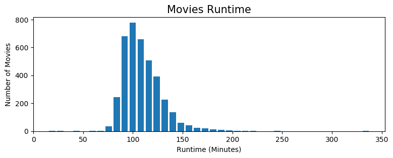

```python
# here, we will be plotting a movies runtime histogram

#setting the graph size(width, height)
plt.figure(figsize=(9,3), dpi = 100)
#x-axis
plt.xlabel('Runtime (Minutes)', fontsize = 10)
#y-axis
plt.ylabel('Number of Movies', fontsize=10)
#Give the name of the graph
plt.title('Movies Runtime', fontsize=15)

#set a histogram plot
plt.hist(movies_df['runtime'], rwidth = .8, bins =40)
#finally, display the plot
plt.show()
```

> Looking at this graph, it’s easy to determine that the graph is skewed to the right. Most of the bulk of movies in our data fall in the 90 - 110 minutes rage.

#### Question #3: Which movies has the highest vote?

```python
movies_df.sort_values(by=['vote_count'], ascending=False).head(1)
```

|  | id | popularity | budget | revenue | original_title | cast | director | runtime | genres | production_companies | vote_count | vote_average | release_year |
| --- | --- | --- | --- | --- | --- | --- | --- | --- | --- | --- | --- | --- | --- |
| 1919 | 27205 | 9.363643 | 160000000.0 | 825500000.0 | Inception | Leonardo DiCaprio\|Joseph Gordon-Levitt\|Ellen P... | Christopher Nolan | 148 | Action\|Thriller\|Science Fiction\|Mystery\|Adventure | Legendary Pictures\|Warner Bros.\|Syncopy | 9767 | 7.9 | 2010 |

```python
movies_df[movies_df['genres'].str.contains("Movie", na=False)].sort_values('vote_average', ascending=False).tail(5)
```

|  | id | popularity | budget | revenue | original_title | cast | director | runtime | genres | production_companies | vote_count | vote_average | release_year |
| --- | --- | --- | --- | --- | --- | --- | --- | --- | --- | --- | --- | --- | --- |
| 8615 | 15691 | 0.273628 | 5000000.0 | 42000000.0 | Doctor Who | Paul McGann\|Eric Roberts\|Daphne Ashbrook\|Sylve... | Geoffrey Sax | 89 | TV Movie\|Adventure\|Drama\|Science Fiction | Universal TV\|20th Century Fox Television\|BBC W... | 35 | 5.6 | 1996 |

#### Question #5: What is the average money needed to make a movie?

```python
# variable to save the average budget
avg = movies_df['budget'].mean()
print('The Average amount or funding needed to make a movie is $' + format(avg, ',.0f') + '(US)')
```

```
The Average amount or funding needed to make a movie is $37,203,697(US)
```

> Now that we know it takes an average of about $37 million dollars to make a movie, lets see what has been historically the average throughout the years.

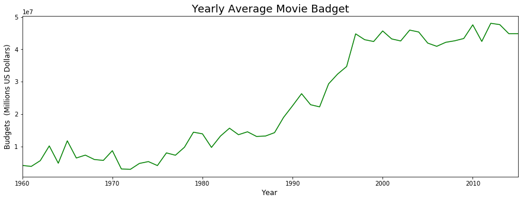

```python
movies_df.groupby('release_year')['budget'].mean().plot(kind='line', figsize = (15, 5), color = 'g')
plt.title('Yearly Average Movie Badget', fontsize = 18)
plt.xlabel('Year', fontsize = 12)
plt.ylabel('Budgets  (Millions US Dollars)', fontsize = 12);
```